# **T3. Visualización**

## Gráfica de dispersión

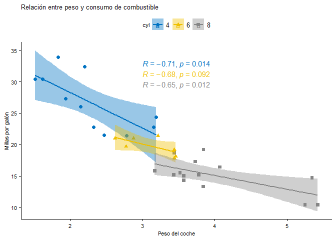

```r
dfm2 <- ggscatter(mtcars, x = "wt", y = "mpg",
                add = "reg.line",# Para agregar la linea de regresión
                conf.int = TRUE, # para agregar el intervalo de confianza
                color = "cyl", palette = "jco", # se aplica un color por grupos para "cyl"
                shape = "cyl"
)+
  stat_cor(aes(color = cyl), label.x = 3) +
  xlab("Peso del coche") + # etiqueta del eje x
  ylab("Millas por galón") + # etiqueta del eje y
  ggtitle("Relación entre peso y consumo de combustible")+ #título del gráfico
theme(axis.text = element_text(size = 8),
            axis.title = element_text(size = 8),
            title = element_text(size = 8))
dfm2
```

El gráfico de la Relación entre peso y consumo de combustible, muestra una tendencia general de los datos, pero no implica una relación causal entre las variables. Es decir, no podemos afirmar que el peso del coche cause el consumo de combustible, o viceversa. Solo podemos decir que hay una asociación estadística entre ambas variables, que se mide por el coeficiente de correlación.

El coeficiente de correlación es un número entre -1 y 1 que indica el grado y la dirección de la relación lineal entre dos variables. Un valor cercano a -1 significa una relación negativa fuerte, es decir, que cuando una variable aumenta la otra disminuye. Un valor cercano a 1 significa una relación positiva fuerte, es decir, que cuando una variable aumenta la otra también aumenta. Un valor cercano a 0 significa una relación débil o nula, es decir, que no hay una tendencia clara entre las variables.

## Gráfico de puntos

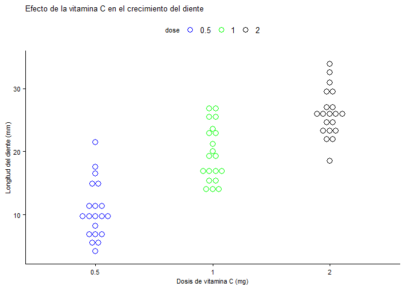

```r
dt <- ggdotplot(ToothGrowth, x = "dose", y = "len",
                color = "dose",
                palette = "jco",
                binwidth = 1) +
      # Añadir nombres a los ejes y un título al gráfico
      labs(x = "Dosis de vitamina C (mg)",
           y = "Longitud del diente (mm)",
           title = "Efecto de la vitamina C en el crecimiento del diente")+
      # para definir una paleta de colores
         scale_color_manual(values = c( "blue","green", "black"))+
            theme(axis.text = element_text(size = 8),
            axis.title = element_text(size = 8),
            title = element_text(size = 8))
dt
```